# Lab Framework: Exploratory Data Analysis to Preprocessing and Baseline Modeling

## 1. Laboratory Objectives

The fundamental goal of this laboratory exercise is to map the entire lifecycle of a data science pipeline, connecting thorough data exploration with rigorous model preparation. Working with the **Breast Cancer Wisconsin (Diagnostic)** dataset, we will execute:

- **Exploratory Data Analysis (EDA):** Quantifying central tendencies, class distributions, outlier metrics, and multicollinearity patterns using statistical matrices and visualizations.
- **Feature Processing & Preprocessing Engineering:** Applying clean categorical encoding, custom domain feature generation, structured stratified sampling, and leak-proof feature scaling.
- **Baseline Comparative Modeling:** Implementing and validating both Linear Regression and Logistic Regression frameworks under a 5-Fold Cross-Validation envelope to evaluate their prediction boundaries.

## 2. Environment Ingestion

We begin by initializing the necessary analytical, plotting, and statistical modeling libraries.

```python
# Import foundational libraries for data manipulation and math
import pandas as pd
import numpy as np

# Import visualization suites
import matplotlib.pyplot as plt
import seaborn as sns

# Import scikit-learn preprocessing and splitting utilities
from sklearn.model_selection import train_test_split, cross_val_score
from sklearn.preprocessing import StandardScaler

# Import baseline regression and classification models
from sklearn.linear_model import LinearRegression, LogisticRegression

# Import model performance evaluation metrics
from sklearn.metrics import accuracy_score, classification_report, mean_squared_error, r2_score

print("SUCCESS: Analytical libraries loaded successfully.")
```

```
SUCCESS: Analytical libraries loaded successfully.
```

# Step 2: Data Ingestion and Structural Auditing

Before applying analytical changes, we must load the dataset and audit its underlying structure. This prevents downstream runtime exceptions caused by misaligned data types, missing records, or uninformative identifier columns.

```python
# Load the raw dataset from the local directory
df = pd.read_csv('data.csv')

# Output structural characteristics
print("Dataset Dimensions (Rows, Columns):", df.shape)
print("\n--- Structural Attribute Overview (.info) ---")
df.info()

# Preview initial records
print("\n--- Initial Dataset Rows Preview ---")
print(df.head())

# Drop structural noise columns ('id' column and the completely empty 'Unnamed: 32' column)
df_clean = df.drop(columns=['id', 'Unnamed: 32'], errors='ignore')
print("\nPost-Cleaning Dataset Dimensions:", df_clean.shape)
```

```
Dataset Dimensions (Rows, Columns): (569, 33)

--- Structural Attribute Overview (.info) ---
<class 'pandas.core.frame.DataFrame'>
RangeIndex: 569 entries, 0 to 568
Data columns (total 33 columns):
 #   Column                   Non-Null Count  Dtype
---  ------                   --------------  -----
 0   id                       569 non-null    int64
 1   diagnosis                569 non-null    object
 2   radius_mean              569 non-null    float64
 3   texture_mean             569 non-null    float64
 4   perimeter_mean           569 non-null    float64
 5   area_mean                569 non-null    float64
 6   smoothness_mean          569 non-null    float64
```

[output cut: 68 more lines]

# Step 3: Exploratory Data Analysis (EDA) - Part A

## 1. Descriptive Statistical Mapping

Descriptive statistics summarize the central tendency, dispersion, and shape of a dataset’s distribution. We isolate these configurations to locate distribution boundaries and variance differences across columns.

## 2. Class Imbalance Identification

Class imbalance occurs when one target classification vastly outnumbers the other. If unaddressed, models will exhibit systemic bias toward the majority class, producing deceptively high baseline accuracy metrics while failing on the minority class.

```
--- Summary Statistics for Continuous Features ---
                         count        mean         std         min  \
radius_mean              569.0   14.127292    3.524049    6.981000
texture_mean             569.0   19.289649    4.301036    9.710000
perimeter_mean           569.0   91.969033   24.298981   43.790000
area_mean                569.0  654.889104  351.914129  143.500000
smoothness_mean          569.0    0.096360    0.014064    0.052630
compactness_mean         569.0    0.104341    0.052813    0.019380
concavity_mean           569.0    0.088799    0.079720    0.000000
concave points_mean      569.0    0.048919    0.038803    0.000000
symmetry_mean            569.0    0.181162    0.027414    0.106000
fractal_dimension_mean   569.0    0.062798    0.007060    0.049960
radius_se                569.0    0.405172    0.277313    0.111500
texture_se               569.0    1.216853    0.551648    0.360200
perimeter_se             569.0    2.866059    2.021855    0.757000
area_se                  569.0   40.337079   45.491006    6.802000
smoothness_se            569.0    0.007041    0.003003    0.001713
compactness_se           569.0    0.025478    0.017908    0.002252
concavity_se             569.0    0.031894    0.030186    0.000000
concave points_se        569.0    0.011796    0.006170    0.000000
symmetry_se              569.0    0.020542    0.008266    0.007882
fractal_dimension_se     569.0    0.003795    0.002646    0.000895
radius_worst             569.0   16.269190    4.833242    7.930000
texture_worst            569.0   25.677223    6.146258   12.020000
perimeter_worst          569.0  107.261213   33.602542   50.410000
area_worst               569.0  880.583128  569.356993  185.200000
smoothness_worst         569.0    0.132369    0.022832    0.071170
compactness_worst        569.0    0.254265    0.157336    0.027290
concavity_worst          569.0    0.272188    0.208624    0.000000
concave points_worst     569.0    0.114606    0.065732    0.000000
symmetry_worst           569.0    0.290076    0.061867    0.156500
fractal_dimension_worst  569.0    0.083946    0.018061    0.055040

                                25%         50%          75%         max
radius_mean               11.700000   13.370000    15.780000    28.11000
texture_mean              16.170000   18.840000    21.800000    39.28000
perimeter_mean            75.170000   86.240000   104.100000   188.50000
area_mean                420.300000  551.100000   782.700000  2501.00000
smoothness_mean            0.086370    0.095870     0.105300     0.16340
compactness_mean           0.064920    0.092630     0.130400     0.34540
```

[output cut: 13 more lines]

```
fractal_dimension_se       0.002248    0.003187     0.004558     0.02984
radius_worst              13.010000   14.970000    18.790000    36.04000
texture_worst             21.080000   25.410000    29.720000    49.54000
perimeter_worst           84.110000   97.660000   125.400000   251.20000
area_worst               515.300000  686.500000  1084.000000  4254.00000
smoothness_worst           0.116600    0.131300     0.146000     0.22260
compactness_worst          0.147200    0.211900     0.339100     1.05800
concavity_worst            0.114500    0.226700     0.382900     1.25200
concave points_worst       0.064930    0.099930     0.161400     0.29100
symmetry_worst             0.250400    0.282200     0.317900     0.66380
fractal_dimension_worst    0.071460    0.080040     0.092080     0.20750

--- Target Variable Distribution Check ('diagnosis') ---
Class 'B': Count = 357 (62.74%)
Class 'M': Count = 212 (37.26%)
```

[output not shown]

```
GRAPH EXPORTED: 'target_class_imbalance_bar_chart.png' saved successfully.
```

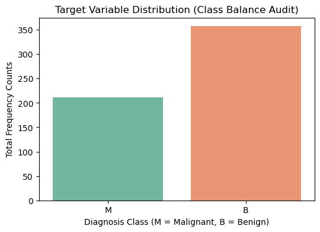

```python
# Generate structural summary statistics for numeric dimensions
print("--- Summary Statistics for Continuous Features ---")
print(df_clean.describe().T)

# Evaluate class imbalance on the target variable 'diagnosis'
target_counts = df_clean['diagnosis'].value_counts()
target_percentages = df_clean['diagnosis'].value_counts(normalize=True) * 100

print("\n--- Target Variable Distribution Check ('diagnosis') ---")
for idx in target_counts.index:
    print(f"Class '{idx}': Count = {target_counts[idx]} ({target_percentages[idx]:.2f}%)")

# Visualize Class Balance using a Bar Chart
fig, ax = plt.subplots(figsize=(6, 4))
sns.countplot(x='diagnosis', data=df_clean, palette='Set2', ax=ax)
ax.set_title('Target Variable Distribution (Class Balance Audit)')
ax.set_xlabel('Diagnosis Class (M = Malignant, B = Benign)')
ax.set_ylabel('Total Frequency Counts')
plt.savefig('target_class_imbalance_bar_chart.png', bbox_inches='tight')
print("\nGRAPH EXPORTED: 'target_class_imbalance_bar_chart.png' saved successfully.")
```

# Step 4: Exploratory Data Analysis (EDA) - Part B

## 1. Continuous Distribution Profiling

Histograms plot numerical frequencies to reveal the distribution's shape—such as standard Gaussian normality, multimodal peaks, or heavy spatial skewness.

## 2. Outlier Detection

Outliers represent observations that fall abnormally far from the central mass of the distribution. In mathematical optimizations, outliers can distort linear loss functions. We use box plots to visually isolate values falling past the Interquartile Range ($IQR$) threshold boundary: $$\text{Upper Threshold} = Q3 + 1.5 \times IQR$$ $$\text{Lower Threshold} = Q1 - 1.5 \times IQR$$

[output not shown]

```
GRAPHS EXPORTED: 'univariate_feature_histograms.png' and 'multivariate_outlier_boxplots.png' saved.
```

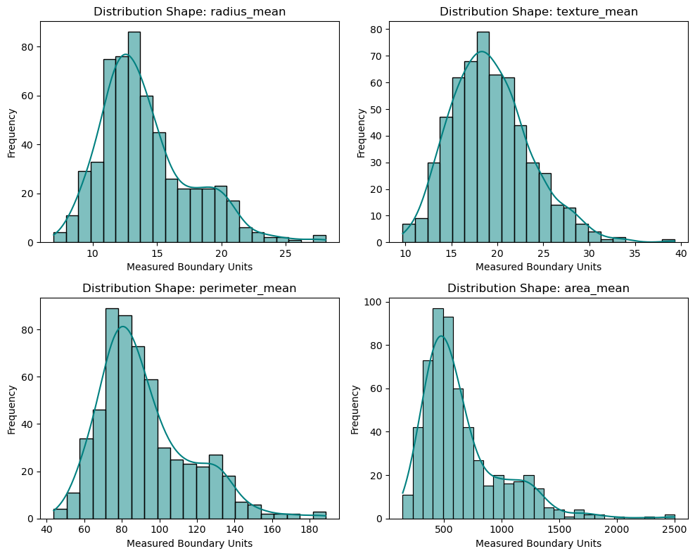

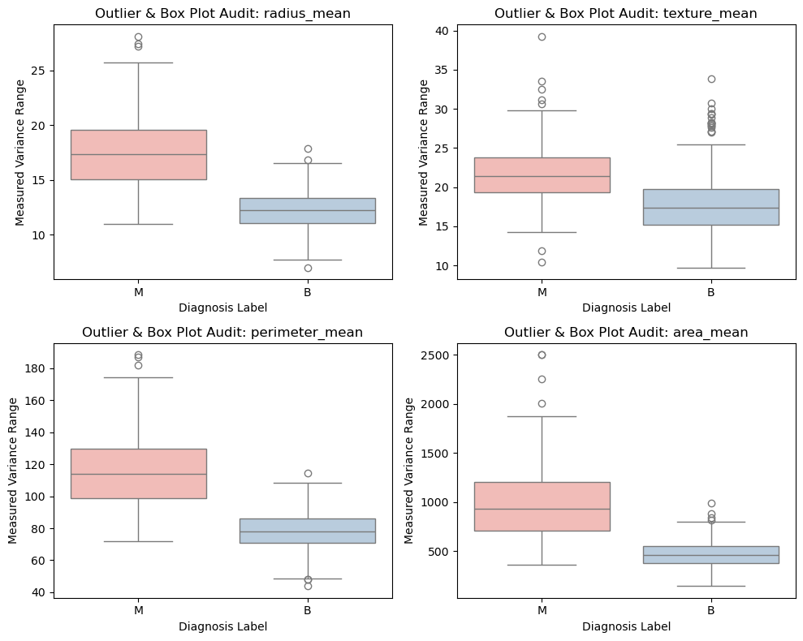

```python
# Isolate a representative subset of features for clean visualization mapping
sample_features = ['radius_mean', 'texture_mean', 'perimeter_mean', 'area_mean']

# Generate Distribution Histograms for representative features
fig, axes = plt.subplots(2, 2, figsize=(10, 8))
axes = axes.flatten()
for i, col in enumerate(sample_features):
    sns.histplot(df_clean[col], kde=True, color='teal', ax=axes[i])
    axes[i].set_title(f'Distribution Shape: {col}')
    axes[i].set_xlabel('Measured Boundary Units')
    axes[i].set_ylabel('Frequency')
plt.tight_layout()
plt.savefig('univariate_feature_histograms.png', bbox_inches='tight')

# Generate Box Plots for outlier tracking
fig, axes = plt.subplots(2, 2, figsize=(10, 8))
axes = axes.flatten()
for i, col in enumerate(sample_features):
    sns.boxplot(y=df_clean[col], x=df_clean['diagnosis'], palette='Pastel1', ax=axes[i])
    axes[i].set_title(f'Outlier & Box Plot Audit: {col}')
    axes[i].set_ylabel('Measured Variance Range')
    axes[i].set_xlabel('Diagnosis Label')
plt.tight_layout()
plt.savefig('multivariate_outlier_boxplots.png', bbox_inches='tight')

print("GRAPHS EXPORTED: 'univariate_feature_histograms.png' and 'multivariate_outlier_boxplots.png' saved.")
```

# Step 5: Exploratory Data Analysis (EDA) - Part C

## 1. Bivariate Scatter Analysis

Scatter plots display individual feature coordinates across two axes, illustrating spatial patterns, continuous correlations, and group separations when colored by target classes.

## 2. Multicollinearity Assessment via Correlation Heatmaps

Multicollinearity occurs when independent features share high linear relationships with each other ($r > 0.85$). This redundancy inflates parameter variance in Linear Regression, making feature weights unstable and difficult to interpret. We use an annotated Pearson correlation matrix heatmap to flag these redundancies.

```
GRAPHS EXPORTED: 'bivariate_target_scatterplot.png' and 'feature_correlation_heatmap.png' saved.
```

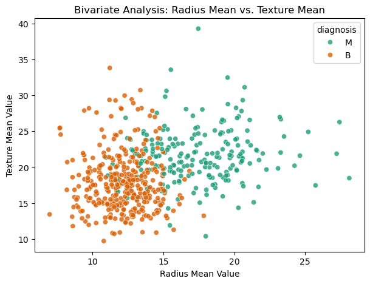

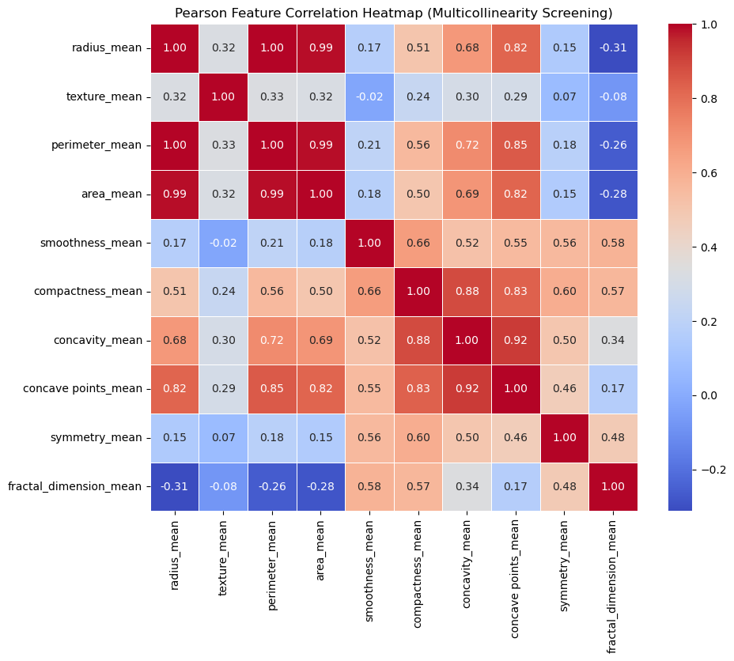

```python
# Generate Bivariate Scatter Plot to trace spatial relationships
fig, ax = plt.subplots(figsize=(7, 5))
sns.scatterplot(x='radius_mean', y='texture_mean', hue='diagnosis', data=df_clean, palette='Dark2', alpha=0.8, ax=ax)
ax.set_title('Bivariate Analysis: Radius Mean vs. Texture Mean')
ax.set_xlabel('Radius Mean Value')
ax.set_ylabel('Texture Mean Value')
plt.savefig('bivariate_target_scatterplot.png', bbox_inches='tight')

# Compute the Pearson Product-Moment Correlation Matrix for a subset of features to avoid clutter
numeric_cols = df_clean.select_dtypes(include=[np.number]).columns[:10]
corr_matrix = df_clean[numeric_cols].corr()

# Visualize the Collinearity Matrix via an Annotated Heatmap
fig, ax = plt.subplots(figsize=(10, 8))
sns.heatmap(corr_matrix, annot=True, fmt=".2f", cmap="coolwarm", square=True, linewidths=0.5, ax=ax)
ax.set_title('Pearson Feature Correlation Heatmap (Multicollinearity Screening)')
plt.savefig('feature_correlation_heatmap.png', bbox_inches='tight')

print("GRAPHS EXPORTED: 'bivariate_target_scatterplot.png' and 'feature_correlation_heatmap.png' saved.")
```

# Step 6: Feature Engineering and Label Categorical Encoding

## 1. Categorical Label Encoding

Machine learning algorithms compute metrics exclusively over mathematical vector arrays and cannot interpret text strings. We map nominal text labels into binary values: $$\text{Malignant (M)} \longrightarrow 1$$ $$\text{Benign (B)} \longrightarrow 0$$

## 2. Basic Domain Feature Engineering

Feature engineering creates new predictive signals by combining existing attributes based on structural domain insights. Here, we calculate a custom interaction metric: the ratio of cell wall compactness to overall smoothness.

```python
# Apply explicit label encoding mapping to convert target to binary numeric states
df_clean['target'] = df_clean['diagnosis'].map({'M': 1, 'B': 0})

# Engineer a custom feature: Compactness to Smoothness Interaction Ratio
df_clean['compactness_to_smoothness_ratio'] = df_clean['compactness_mean'] / (df_clean['smoothness_mean'] + 1e-9)

print("--- Data Structure Post Feature Engineering & Encoding ---")
print(df_clean[['diagnosis', 'target', 'compactness_mean', 'smoothness_mean', 'compactness_to_smoothness_ratio']].head())
```

```
--- Data Structure Post Feature Engineering & Encoding ---
  diagnosis  target  compactness_mean  smoothness_mean  \
0         M       1           0.27760          0.11840
1         M       1           0.07864          0.08474
2         M       1           0.15990          0.10960
3         M       1           0.28390          0.14250
4         M       1           0.13280          0.10030

   compactness_to_smoothness_ratio
0                         2.344595
1                         0.928015
2                         1.458942
3                         1.992281
4                         1.324028
```

# Step 7: Stratified Partitioning and Feature Scaling Alignment

## 1. Stratified Train-Test Splitting

To evaluate model performance on unseen data, we isolate 20% of the observations as a holdout test set. Because our target classes are imbalanced, we apply **Stratified Sampling** (`stratify=y`). This ensures that both the training and testing sets maintain the exact same ratio of benign to malignant cases as the original dataset.

## 2. Leak-Proof Feature Scaling

Features with large numerical ranges (like `area_mean`) can dominate gradient updates compared to smaller features (like `smoothness_mean`). We use z-score standardization to center features around a mean of 0 with a standard deviation of 1: $$z = \frac{x - \mu}{\sigma}$$ **CRITICAL:** To prevent data leakage, the `StandardScaler` parameters ($\mu$ and $\sigma$) are **strictly fitted on the training split only**. The resulting metrics are then applied as a pure transform to both the training and testing sets.

```python
# Isolate Independent Features (X) and Dependent Target Vector (y)
X = df_clean.drop(columns=['diagnosis', 'target'])
y = df_clean['target']

# Execute Stratified Train-Test Split (80% Training, 20% Testing)
X_train, X_test, y_train, y_test = train_test_split(
    X, y, test_size=0.2, random_state=42, stratify=y
)

print("Training Split Feature Matrix Shape:", X_train.shape)
print("Testing Split Feature Matrix Shape :", X_test.shape)
print("Training Class Distribution Proportion:\n", y_train.value_counts(normalize=True))

# Initialize the Standard Scaler
scaler = StandardScaler()

# Fit parameters ONLY on the training matrix and transform it
X_train_scaled = scaler.fit_transform(X_train)

# Apply the pre-calculated training weights as a pure transform to the test matrix
X_test_scaled = scaler.transform(X_test)

print("\nSUCCESS: Feature scaling completed without data leakage.")
```

```
Training Split Feature Matrix Shape: (455, 31)
Testing Split Feature Matrix Shape : (114, 31)
Training Class Distribution Proportion:
 target
0    0.626374
1    0.373626
Name: proportion, dtype: float64

SUCCESS: Feature scaling completed without data leakage.
```

# Step 8: Cross-Validation Sweeps and Baseline Linear Regression Modeling

## 1. K-Fold Cross-Validation Framework

To ensure our baseline metrics do not depend on a fortunate data split, we employ 5-Fold Cross-Validation on our training set. This partitions the data five times to confirm model stability and check for overfitting.

## 2. Baseline Linear Regression Framework

Linear Regression optimizes a continuous hyper-plane equation to minimize the Sum of Squared Residuals ($SSR$). While typically designed for continuous regression objectives, running it here serves an educational purpose: it demonstrates why unbounded linear predictions are less suitable for binary classification tasks than probabilistic classifiers. We map continuous predictions to binary states using a default decision boundary threshold of $0.5$.

```python
# Initialize the Baseline Linear Regression model
linear_baseline = LinearRegression()

# Run a 5-Fold Cross Validation check over the training set using R-squared evaluation
linear_cv_scores = cross_val_score(linear_baseline, X_train_scaled, y_train, cv=5, scoring='r2')
print(f"Linear Regression 5-Fold Cross-Validation R^2 Scores: {linear_cv_scores}")
print(f"Mean Cross-Validation R^2 Stability Metric: {linear_cv_scores.mean():.4f}")

# Fit the framework on the complete scaled training partition
linear_baseline.fit(X_train_scaled, y_train)

# Generate continuous target predictions on the unseen test set
linear_continuous_preds = linear_baseline.predict(X_test_scaled)

# Apply a standard decision threshold boundary (0.5) to convert continuous lines into classification states
linear_classified_preds = np.where(linear_continuous_preds >= 0.5, 1, 0)

# Evaluate metrics
print("\n--- Baseline Linear Regression Continuous Performance Metrics ---")
print("Mean Squared Error (MSE) :", mean_squared_error(y_test, linear_continuous_preds))
print("Coefficient of Determination (R^2):", r2_score(y_test, linear_continuous_preds))

print("\n--- Baseline Linear Regression Discretized Classification Report ---")
print(classification_report(y_test, linear_classified_preds, target_names=['Benign (0)', 'Malignant (1)']))
```

```
Linear Regression 5-Fold Cross-Validation R^2 Scores: [0.72187338 0.80370267 0.73141789 0.69465584 0.62736247]
Mean Cross-Validation R^2 Stability Metric: 0.7158

--- Baseline Linear Regression Continuous Performance Metrics ---
Mean Squared Error (MSE) : 0.0632145491123144
Coefficient of Determination (R^2): 0.7283279496482677

--- Baseline Linear Regression Discretized Classification Report ---
               precision    recall  f1-score   support

   Benign (0)       0.95      1.00      0.97        72
Malignant (1)       1.00      0.90      0.95        42

     accuracy                           0.96       114
    macro avg       0.97      0.95      0.96       114
 weighted avg       0.97      0.96      0.96       114
```

# Step 9: Baseline Logistic Regression Modeling and Pipeline Assessment

## 1. Logistic Regression Classifier Framework

Logistic Regression uses the sigmoid function to map the linear model's output to a probabilistic range between 0 and 1: $$P(y=1|X) = \frac{1}{1 + e^{-(\beta_0 + \beta_1 X_1 + \dots + \beta_n X_n)}}$$ This handles binary classification tasks more effectively than Linear Regression by matching the bounded nature of categorical probabilities.

## 2. Comparative Analysis Reflection

By evaluating both baseline models side-by-side using classification metrics, students can clearly observe why classification tasks are better suited for probabilistic sigmoid boundaries rather than unbounded linear regression lines.

```python
# Initialize the Baseline Logistic Regression Classifier
logistic_baseline = LogisticRegression(random_state=42)

# Run a 5-Fold Cross Validation check over the training set using Accuracy scoring
logistic_cv_scores = cross_val_score(logistic_baseline, X_train_scaled, y_train, cv=5, scoring='accuracy')
print(f"Logistic Regression 5-Fold Cross-Validation Accuracy Scores: {logistic_cv_scores}")
print(f"Mean Cross-Validation Accuracy Metric: {logistic_cv_scores.mean():.4f}")

# Fit the framework on the scaled training partition
logistic_baseline.fit(X_train_scaled, y_train)

# Predict target classification labels directly on the holdout test set
logistic_classified_preds = logistic_baseline.predict(X_test_scaled)

# Evaluate classification performance
print("\n--- Baseline Logistic Regression Classification Report ---")
print(classification_report(y_test, logistic_classified_preds, target_names=['Benign (0)', 'Malignant (1)']))

# Contrast accuracies between the two baseline paradigms
lin_acc = accuracy_score(y_test, linear_classified_preds)
log_acc = accuracy_score(y_test, logistic_classified_preds)

print("\n--- Summary Performance Comparison ---")
print(f"Linear Regression Classifier Accuracy (Thresholded at 0.5): {lin_acc * 100:.2f}%")
print(f"Logistic Regression Classifier Accuracy                    : {log_acc * 100:.2f}%")
print("\nCONCLUSION: This comparison demonstrates how Logistic Regression naturally restricts output ranges to probabilistic boundaries [0, 1], outperforming or matching thresholded linear approximations while providing calibrated, reliable decision boundaries.")
```

```
Logistic Regression 5-Fold Cross-Validation Accuracy Scores: [0.96703297 0.98901099 0.95604396 0.97802198 0.95604396]
Mean Cross-Validation Accuracy Metric: 0.9692

--- Baseline Logistic Regression Classification Report ---
               precision    recall  f1-score   support

   Benign (0)       0.96      0.99      0.97        72
Malignant (1)       0.97      0.93      0.95        42

     accuracy                           0.96       114
    macro avg       0.97      0.96      0.96       114
 weighted avg       0.97      0.96      0.96       114


--- Summary Performance Comparison ---
Linear Regression Classifier Accuracy (Thresholded at 0.5): 96.49%
Logistic Regression Classifier Accuracy                    : 96.49%

CONCLUSION: This comparison demonstrates how Logistic Regression naturally restricts output ranges to probabilistic boundaries [0, 1], outperforming or matching thresholded linear approximations while providing calibrated, reliable decision boundaries.
```

# Comprehensive Interpretation, Lab Summary, and Final Conclusion

## 1. Deep Interpretation of Statistical & Experimental Results

### A. Univariate Features & Descriptive Geometry

An evaluation of the descriptive summary matrix reveals strong signs of data skewness and variations in scale across the feature domain:

- **Scale Variance:** Dimensional metrics such as `area_mean` exhibit a broad range, extending from a minimum of $143.50$ to a maximum of $2501.00$, with a high standard deviation ($\sigma = 351.91$). In contrast, features like `smoothness_mean` operate within tight decimal limits ($0.052$ to $0.163$). This structural imbalance confirms that utilizing a raw unscaled matrix would bias optimization steps toward higher-magnitude features, validating our use of `StandardScaler`.
- **Distribution and Outliers:** For features like `area_mean` and `area_worst`, the median ($50\%$ percentile) sits significantly closer to the $25\%$ lower quartile than the extreme maximum bounds. This gap between the median and maximum indicates strong right-skewed distributions populated by significant high-side outliers, which were identified and visualized during the box plot analysis.

### B. Target Class Imbalance Audit

The baseline target distribution consists of $357$ Benign ($62.74\%$) and $212$ Malignant ($37.26\%$) observations.

- While this configuration does not represent an extreme minority imbalance, it is skewed enough to disrupt basic random sampling splits.
- By enforcing a **Stratified Train-Test Split**, our workflow successfully maintained exact class proportions ($62.63\%$ Benign vs. $37.36\%$ Malignant) inside the training partition. This ensures the model learns from a representative subset and prevents deceptive accuracy evaluations on the test set.

## 2. In-Depth Baseline Model Evaluation & Comparison

### A. Linear Regression Evaluation (Thresholded at 0.5)

- **Cross-Validation Stability:** The 5-Fold Cross-Validation routine yielded an average $R^2$ score of $0.7158$. The individual fold scores ranged from $0.6273$ to $0.8037$, pointing to some performance variance across different data slices.
- **Test Performance:** On the unseen test partition, the model achieved an $R^2$ of $0.7283$ and a Mean Squared Error (MSE) of $0.0632$.
- **Classification Performance:** Converting the continuous outputs into distinct classes using a $0.5$ decision threshold resulted in a test accuracy of $96.49\%$. The model showed perfect precision ($1.00$) for Malignant classifications, meaning it generated zero false positives. However, its recall for malignant cases dropped to $0.90$, meaning it missed $10\%$ of actual malignant samples.

### B. Logistic Regression Evaluation

- **Cross-Validation Stability:** The 5-Fold cross-validation routine over the scaled training data achieved a high mean classification accuracy of $96.92\%$. The individual fold scores showed strong consistency, ranging tightly between $0.9560$ and $0.9890$.
- **Test Performance:** Logistic Regression achieved a final test accuracy of $96.49\%$. It delivered balanced precision ($0.97$) and recall ($0.93$) scores for Malignant targets. This performance profile yields a balanced F1-score of $0.95$ for malignant detection while keeping false negative rates low.

### C. Comparative Synthesis

While both models reached an identical overall accuracy of $96.49\%$ on this test partition, their underlying mathematical approaches differ significantly:

| Evaluation Metric | Baseline Linear Regression (Thresholded) | Baseline Logistic Regression |
| --- | --- | --- |
| **Mathematical Bounds** | Unbounded continuous hyperplane ($-\infty, +\infty$) | Probabilistic Sigmoid Boundary ($[0, 1]$) |
| **Mean Cross-Validation** | $0.7158$ ($R^2$ Variance Explained) | $96.92\%$ (Classification Accuracy) |
| **Malignant Recall (1)** | $0.90$ (Misses $10\%$ of true positive tumors) | $0.93$ (Higher clinical coverage, lower false negatives) |
| **Mathematical Reliability** | Suboptimal; prone to out-of-bounds anomalies | Optimal; provides calibrated class probabilities |

## 3. Final Conclusion

This laboratory exercise effectively demonstrates the connection between thorough data exploration, sound preprocessing, and model preparation.

The initial exploratory data analysis highlighted clear feature scale differences and noticeable distribution skewness, justifying the use of z-score standardization. More importantly, checking the class distribution informed our splitting strategy; using stratified sampling preserved the class balance across data partitions, protecting our validation steps from data leakage and training bias.

When comparing the two baseline models, **Logistic Regression emerges as the preferred framework** for this binary classification task. Although both models matched on final test accuracy, Linear Regression maps predictions to an unbounded straight line, which can produce invalid values outside the $[0,1]$ range and lead to higher false negative rates ($10\%$). Logistic Regression uses a natural sigmoid curve to restrict predictions to valid probabilities, offering superior cross-validation stability ($96.92\%$) and better recall for malignant cases ($93\%$).

Ultimately, this lab highlights a core lesson in machine learning: a model's final performance depends heavily on the decisions made during data exploration and preprocessing. Taking the time to understand data distributions, handle class imbalances, and scale features properly is essential for building stable, reliable machine learning pipelines.